# TeoNAM STAM — GWAS Manhattan with candidate genes (Chen 2019 Fig 4C)

Empirical-truth validation: reproduce Chen 2019 STAM on real TeoNAM genotypes

Author

Fausto Rodríguez-Zapata

Published

July 6, 2026

**What this is.** The STAM GWAS Manhattan (Chen 2019 Fig 4C) reproduced on the TeoNAM genotypes, with the domestication candidate genes placed at their **real B73 v5 coordinates** (MaizeGDB `genemodel_locus` → `b73_gene_coords`), a red star at each gene’s genomic position, and the LOD = 5 dotted significance line.

This notebook **loads pre-computed CSVs and plots** (compute lives in the `agent/` scripts): the per-marker GWAS scans (`teonam_stam_gwas_scan.R` interpolated / `teonam_stam_gwas_family_imputed.R` family-imputed) and the candidate-gene overlap (`teonam_candidate_overlap.R`). We show both the **family-imputed** scan (natural scatter) and the **interpolated/densified** scan (block-terraced — the artifact of step-interpolated genotypes, see below).

```r
library(here)
library(data.table)
library(ggplot2)
library(fastman)
library(ggrepel)
library(ggtext)
library(scales)
library(cowplot)
```

```r
# Coordinate transformer replicating fastman_gg's internal x layout, so we can
# place gene labels / lines at arbitrary (chr, bp). From inv4m make_manhattan_plots.Rmd.
get_transformer <- function(m) {
  cmat <- do.call(rbind, lapply(
    split(m[order(m$CHR, m$BP), ], m$CHR[order(m$CHR, m$BP)]),
    function(d) {
      data.frame(
        CHR = d$CHR[1], min_bp = min(d$BP),
        width = max(d$BP) - min(d$BP),
        medgap = if (nrow(d) > 1) median(diff(sort(d$BP))) else 1
      )
    }
  ))
  cmat <- cmat[order(cmat$CHR), ]
  maxgap <- max(cmat$medgap, na.rm = TRUE)
  numc <- nrow(cmat)
  cmat$base <- 0
  cmat$midp <- 0
  cmat$midp[1] <- cmat$width[1] / 2
  for (i in 2:numc) {
    cmat$base[i] <- cmat$base[i - 1] + cmat$width[i - 1] + maxgap
    cmat$midp[i] <- cmat$base[i] + cmat$width[i] / 2
  }
  fac <- numc / cmat$midp[numc]
  cmat$basef <- fac * cmat$base
  function(chr, bp) {
    i <- match(chr, cmat$CHR)
    fac * (bp - cmat$min_bp[i]) + cmat$basef[i]
  }
}

LOD <- 5 # Chen 2019: P < 1e-5 (LOD = 5)

#' STAM GWAS Manhattan with candidate genes at their true v5 positions.
#' Odd chromosomes black, even gray75; y-axis expanded one major-tick unit above
#' the top tick; gene labels repelled into the headroom above the maximum peak
#' (segments back to the red star at each gene's local peak).
#' @param scan_csv per-marker scan (SNP, CHR, BP[v5], P)
#' @param title    plot title
#' @param out_png  optional path to save a PNG
plot_stam_manhattan <- function(scan_csv, title, out_png = NULL) {
  scan <- as.data.frame(fread(scan_csv))
  scan <- scan[is.finite(scan$P) & scan$P > 0, ]
  m <- scan[order(scan$CHR, scan$BP), c("SNP", "CHR", "BP", "P")]

  ov <- fread(here("results/sim/teonam/stam_candidate_overlap.csv")) # symbol, chr, start (v5)
  # star height = local max -log10P within +/-500 kb IN THIS scan
  ov[, y := vapply(seq_len(.N), function(i) {
    w <- m$P[m$CHR == chr[i] & abs(m$BP - start[i]) <= 5e5]
    if (length(w)) -log10(min(w)) else NA_real_
  }, numeric(1))]
  tr <- get_transformer(m)
  ov[, BPn := tr(chr, start)]
  ov <- ov[is.finite(y)]

  mp <- -log10(min(m$P)) # maximum peak
  ticks <- pretty(c(0, mp))
  unit <- diff(ticks)[1]
  ytop <- max(ticks) + unit # one major-tick unit of headroom

  p <- fastman_gg(
    m = m, snp = "SNP", col = c("black", "gray75"), maxP = mp,
    genomewideline = NULL, suggestiveline = NULL,
    ylab = expression(-log[10](italic(P))), xlab = ""
  ) +
    geom_hline(yintercept = LOD, linetype = "dotted", linewidth = 0.7, color = "black") +
    geom_point(
      data = ov, aes(x = BPn, y = y), inherit.aes = FALSE,
      shape = 8, size = 3, stroke = 1, color = "red"
    ) +
    ggrepel::geom_text_repel(
      data = ov, aes(x = BPn, y = y, label = symbol),
      inherit.aes = FALSE, fontface = "italic", size = 5,
      segment.color = "grey50", min.segment.length = 0, box.padding = 0.5,
      max.overlaps = Inf, ylim = c(mp + 0.3 * unit, ytop)
    ) + # above the max peak
    ggtitle(title) +
    theme_classic(base_size = 18) +
    scale_y_continuous(
      breaks = ticks, limits = c(0, ytop),
      expand = expansion(mult = c(0.01, 0))
    ) +
    theme(
      plot.title = element_markdown(hjust = 1, size = 16, face = "bold"),
      legend.position = "none",
      panel.grid.major.y = element_line(color = "grey90", linewidth = 0.2)
    )

  if (!is.null(out_png)) ggsave(out_png, p, width = 9, height = 4.6, dpi = 200, bg = "white")
  p
}

#' Chen 2019 Fig 4A: JLM QTL genomic distribution as a lollipop plot.
#' Full 10-chromosome axis is obtained by passing the dense scan to fastman_gg
#' with fully transparent points (col = transparent); the JLM QTL are overlaid as
#' blue stems + points, candidate genes labeled bold-italic above.
#' @param jlm_txt  TASSEL StepwiseOLSModelFitter output (stam_jlm_1.txt): Name,
#'   Locus, Position (v5 bp), `pr>F`
#' @param scan_csv dense per-marker scan, only used (transparent) to lay out the axis
plot_stam_lollipop <- function(jlm_txt, scan_csv, title, out_png = NULL) {
  scan <- as.data.frame(fread(scan_csv))
  scan <- scan[is.finite(scan$P) & scan$P > 0, ]
  maxis <- scan[order(scan$CHR, scan$BP), c("SNP", "CHR", "BP", "P")]

  j <- fread(jlm_txt)
  j <- j[!(Name %in% c("mean", "Family", "Error"))]
  q <- data.table(
    SNP = j$Name, CHR = as.integer(j$Locus), BP = as.integer(j$Position),
    logP = -log10(as.numeric(j$`pr>F`))
  )
  ov <- fread(here("results/sim/teonam/stam_candidate_overlap.csv")) # symbol, chr, start (v5)
  ov <- ov[symbol %in% c("ts2", "tb1", "tru1", "zmm16", "tsh4")] # JLM Fig-4A candidates (an1 is GWAS-only)
  q[, gene := ""] # assign each candidate gene to its NEAREST JLM QTL (1:1)
  for (i in seq_len(nrow(ov))) {
    idx <- which(q$CHR == ov$chr[i])
    if (length(idx)) {
      k <- idx[which.min(abs(q$BP[idx] - ov$start[i]))]
      q$gene[k] <- ov$symbol[i]
    }
  }
  tr <- get_transformer(maxis)
  q[, BPn := tr(CHR, BP)]

  maxlogP <- max(q$logP)
  brks <- seq(0, floor(maxlogP / 10) * 10, by = 10)
  ytop <- maxlogP * 1.18 # headroom for the top label

  p <- fastman_gg(
    m = maxis, snp = "SNP", col = c("#00000000", "#00000000"),
    maxP = maxlogP, genomewideline = NULL, suggestiveline = NULL,
    ylab = expression(-log[10](italic(P))), xlab = ""
  ) +
    geom_segment(
      data = q, aes(x = BPn, xend = BPn, y = 0, yend = logP),
      inherit.aes = FALSE, color = "blue", linewidth = 0.5
    ) +
    geom_point(
      data = q, aes(x = BPn, y = logP), inherit.aes = FALSE,
      color = "blue", size = 2.5
    ) +
    ggrepel::geom_text_repel(
      data = q[gene != ""], aes(x = BPn, y = logP, label = gene),
      inherit.aes = FALSE, fontface = "bold.italic", size = 5,
      segment.color = NA, box.padding = 0.4, point.padding = 0.3,
      nudge_y = 0.05 * maxlogP, seed = 1, max.overlaps = Inf
    ) +
    ggtitle(title) + theme_classic(base_size = 18) +
    scale_y_continuous(breaks = brks, limits = c(0, ytop), expand = expansion(mult = c(0.01, 0))) +
    theme(
      plot.title = element_markdown(hjust = 1, size = 16, face = "bold"),
      legend.position = "none",
      panel.grid.major.y = element_line(color = "grey90", linewidth = 0.2)
    )
  if (!is.null(out_png)) ggsave(out_png, p, width = 9, height = 4, dpi = 200, bg = "white")
  p
}

#' Coverage-sweep line-Manhattan (geom_line, one line per coverage).
#' −log10P vs genomic position along the union grid; `group = interaction(CHR,
#' coverage)` so lines never connect across chromosomes. Color = coverage on a
#' viridis ramp, the λ = ∞ truth baseline in black. LOD = 5 dotted. NO gene labels.
#' Reused for the control / nNIL / RTIGER panels of the degradation composite.
#' @param sweep_csv combined sweep CSV (SNP, CHR, BP[v5], P, coverage; coverage=Inf
#'   for the λ=∞ baseline rows)
#' @param title panel title (markdown)
#' @param legend show the coverage legend (FALSE for composite panels sharing one)
#' @param base_size theme base size
plot_sweep_line <- function(sweep_csv, title, legend = TRUE, base_size = 14) {
  sw <- as.data.table(fread(sweep_csv))
  sw <- sw[is.finite(P) & P > 0]
  sw[, logP := -log10(P)]
  # x layout from the union grid (every coverage carries the identical marker set)
  tr <- get_transformer(as.data.frame(sw[coverage == sw$coverage[1], .(CHR, BP)]))
  sw[, BPn := tr(CHR, BP)]

  cov_levels <- c("0.1", "0.2", "0.5", "1", "5", "10", "20", "∞") # ∞ = infinity
  sw[, cov_lab := factor(ifelse(is.finite(coverage), formatC(coverage), "∞"),
    levels = cov_levels
  )]
  pal <- c(grDevices::hcl.colors(7, "viridis"), "black")
  names(pal) <- cov_levels
  axis_df <- sw[, .(mid = (min(BPn) + max(BPn)) / 2), by = CHR][order(CHR)]
  ytop <- max(sw$logP) * 1.04

  ggplot(
    sw[order(coverage, CHR, BP)],
    aes(x = BPn, y = logP, color = cov_lab, group = interaction(CHR, coverage))
  ) +
    geom_line(linewidth = 0.4) +
    geom_hline(yintercept = LOD, linetype = "dotted", linewidth = 0.7, color = "grey30") +
    scale_color_manual(values = pal, name = "coverage (×)", drop = FALSE) +
    scale_x_continuous(breaks = axis_df$mid, labels = axis_df$CHR, expand = c(0.01, 0)) +
    scale_y_continuous(limits = c(0, ytop), expand = expansion(mult = c(0.01, 0))) +
    labs(x = "chromosome", y = expression(-log[10](italic(P))), title = title) +
    theme_classic(base_size = base_size) +
    theme(
      plot.title = element_markdown(hjust = 0, size = base_size, face = "bold"),
      panel.grid.major.y = element_line(color = "grey90", linewidth = 0.2),
      legend.position = if (legend) "right" else "none"
    )
}
```

## JLM QTL genomic distribution (Fig 4A)

The STAM QTL detected by JLM as a lollipop plot across all 10 chromosomes (height = −log10 P from TASSEL’s stepwise model), candidate genes bold-italic above the corresponding QTL. Reproduces Chen 2019 Fig 4A.

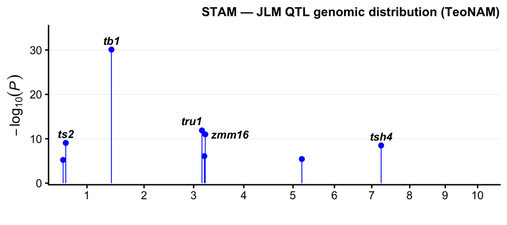

```r
p_lolli <- plot_stam_lollipop(
  here("data/teonam/tassel/stam_jlm_1.txt"),
  here("data/teonam/stam_gwas_scan_family_imputed.csv"),
  "STAM — JLM QTL genomic distribution (TeoNAM)",
  here("results/sim/teonam/stam_jlm_lollipop.png")
)
p_lolli
```

## Family-imputed genotypes (the faithful Fig 4C)

Each marker tested only on its actually-typed lines — natural GWAS scatter.

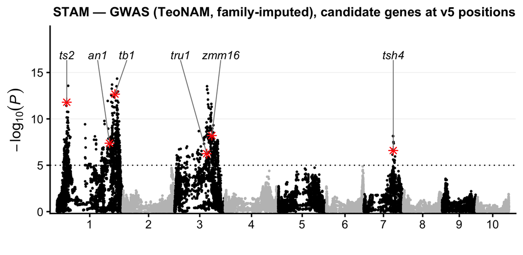

```r
p_unimp <- plot_stam_manhattan(
  here("data/teonam/stam_gwas_scan_family_imputed.csv"),
  "STAM — GWAS (TeoNAM, family-imputed), candidate genes at v5 positions",
  here("results/sim/teonam/stam_gwas_manhattan_annotated.png")
)
p_unimp
```

## Step-interpolated grid — artifact only

The same scan on the step-interpolated full GWAS set (`teonam_map_v5_gwas`, 51,004 markers, cross-family gaps densified). This is shown purely to document the interpolation artifact. Ancestry is a piecewise-constant block signal, so step interpolation makes contiguous markers identical → identical p-values → **terraced plateaus** (peaks still correctly located). The GWAS figure above uses the same markers *without* densification (family-imputed, per-marker).

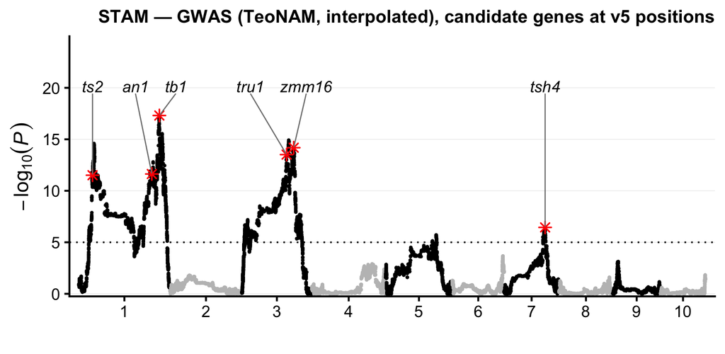

```r
p_interp <- plot_stam_manhattan(
  here("data/teonam/stam_gwas_scan_interpolated.csv"),
  "STAM — GWAS (TeoNAM, interpolated), candidate genes at v5 positions",
  here("results/sim/teonam/stam_gwas_manhattan_interpolated_annotated.png")
)
p_interp
```

## Composite (Fig 4A lollipop + Fig 4C family-imputed + interpolated)

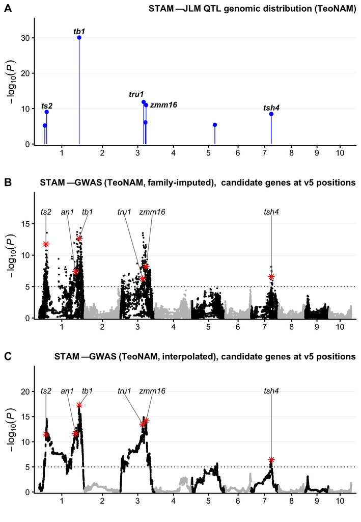

```r
composite <- cowplot::plot_grid(
  p_lolli, p_unimp, p_interp,
  ncol = 1, labels = c("A", "B", "C"), label_size = 20, align = "v", axis = "lr"
)
ggsave(here("results/sim/teonam/stam_composite.png"), composite,
  width = 9, height = 13, dpi = 200, bg = "white"
)
composite
```

## RTIGER ancestry vs sequencing coverage (degradation sweep)

The panel-C baseline above is the **λ = ∞, perfect-caller** curve (GWAS on the interpolated *truth* genotypes). All sweeps below run on the same full **51,004**-marker GWAS grid as the Fig-4C panels above. Here we ask how low-coverage sequencing degrades that signal **through the RTIGER ancestry caller**: for each family × coverage `λ ∈ {0.1, 0.2, 0.5, 1, 5, 10, 20}×` we simulate reads from the real genotypes (`.draw_counts`, `pi_floor=0, k_decay=1, error=0.01`), call ancestry with `call_ancestry(caller = "rtiger", rigidity = 2)` (the calibrated `rigidity_star`), step-interpolate the recovered block onto the same union grid, and rerun the same `STAM ~ Family + marker` scan. Compute lives in `scripts/teonam_rtiger_sweep.R --generate`; this chunk only **loads** the combined sweep CSV and plots.

The read as a **line-Manhattan** (`geom_line`, one line per coverage; chromosomes never connect because `group = interaction(CHR, coverage)`): coverage on a viridis ramp, the λ = ∞ truth baseline in **black** as the reference curve, LOD = 5 dotted. The striking result is how **robust** RTIGER is — ancestry is a long-block signal, so even 0.1× (~9.5 % of markers carrying a read) reconstructs the blocks well enough that the *tb1* peak only slips from ≈17.3 (baseline) to ≈16.1. Degradation is real but lives mostly in HET recovery (het-recall 0.77 at 0.1× → 1.00 at ≥20×), not in the additive QTL peaks.

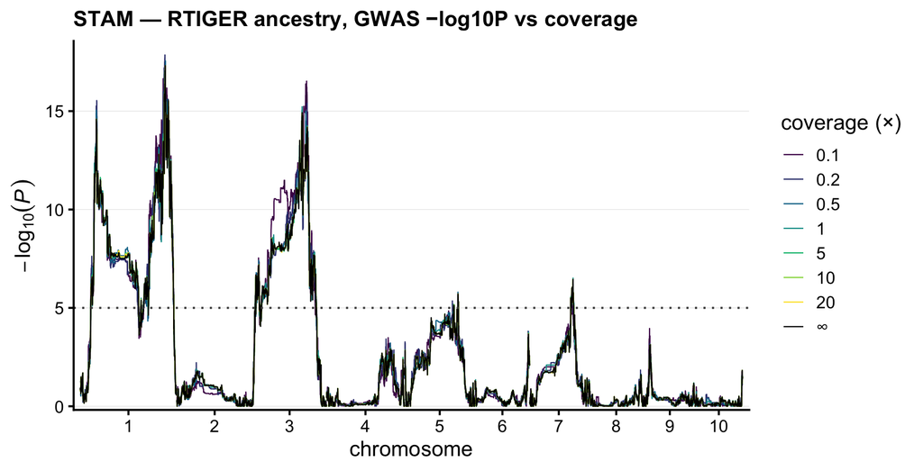

```r
p_sweep <- plot_sweep_line(
  here("results/sim/teonam/stam_gwas_rtiger_sweep.csv"),
  "STAM — RTIGER ancestry, GWAS −log10P vs coverage",
  base_size = 15
)
ggsave(here("results/sim/teonam/stam_gwas_rtiger_sweep_manhattan.png"),
  p_sweep,
  width = 9, height = 4.6, dpi = 200, bg = "white"
)
p_sweep
```

## Coverage-degradation composite: interpolation control / nNIL / RTIGER / LB-Impute

The four-panel contrast (`agent/teonam-control-sweep-plan.md`). All four degrade the **identical** truth mosaics over the same coverage grid `λ ∈ {0.1, 0.2, 0.5, 1, 5, 10, 20}×` (+ the λ = ∞ interpolated-truth baseline) and feed the same `STAM ~ Family + marker` GWAS — only the genotype caller differs:

- **A — interpolation control** (`nilHMM::call_gl(prior = "hwe")` + per-RIL step-interpolation; `scripts/teonam_control_sweep.R`): the deliberately het-prone no-HMM caller — a single ALT read is called HET via the `2p(1−p)` HWE prior term.
- **B — nNIL** (`call_ancestry(caller = "nnil", rrate = rrate_star, err = 0.01)`, `f_1 = 0.08`, `f_2 = 0.15`; `scripts/teonam_nnil_sweep.R`): count emission + geometric duration.
- **C — RTIGER** (`caller = "rtiger", rigidity = 2`; `scripts/teonam_rtiger_sweep.R`): count emission + rigidity duration.
- **D — LB-Impute** (`call_ancestry(caller = "lbimpute", unit = "cm", recombdist = 50)`; `scripts/teonam_lbimpute_sweep.R`): coverage-aware emission + distance-dependent (map-aware cM) transition with a double-recombination penalty, full-chromosome Viterbi (nilHMM native port of Fragoso et al. 2014).

The **contrast is het handling**. The three duration/distance-aware HMMs (B, C, D) tie neighbouring markers into ancestry blocks, so a lone ALT read cannot open a het call — het-call fraction stays near the ~8 % truth level and the STAM peaks hold near the baseline down to 0.1×. LB-Impute (D) is the most aggressive smoother: at 0.1× it actually **over-shoots** the truth peak (*tb1* ≈19.4 vs ≈17.3 baseline) — the signature of long imputed homozygous blocks amplifying the terraced pseudo-replication of the duplicate-cM markers. The control (A) decides each site independently, so at low coverage the HWE prior inflates het to ~20 % (het **excess**) and the *tb1* peak degrades the other way (≈13.4 at 0.1× vs ≈17.3 baseline). `geom_line`, colored by coverage, no gene labels, LOD = 5, chromosomes never connect (`group = interaction(CHR, coverage)`).

```r
het_ctrl <- fread(here("results/sim/teonam/stam_control_het_fraction.csv"))[, .(coverage, control = round(het_frac, 3))]
het_nnil <- fread(here("results/sim/teonam/stam_nnil_het_fraction.csv"))[, .(coverage, nnil = round(het_frac, 3))]
het_tab <- merge(het_ctrl, het_nnil, by = "coverage")
het_tab[] # HET-call fraction vs coverage: control (het excess at low λ) vs nNIL (flat ~truth)
```

```
Key: <coverage>
   coverage control  nnil
      <num>   <num> <num>
1:      0.1   0.201 0.084
2:      0.2   0.202 0.080
3:      0.5   0.204 0.080
4:      1.0   0.204 0.081
5:      5.0   0.122 0.082
6:     10.0   0.089 0.082
7:     20.0   0.082 0.081
```

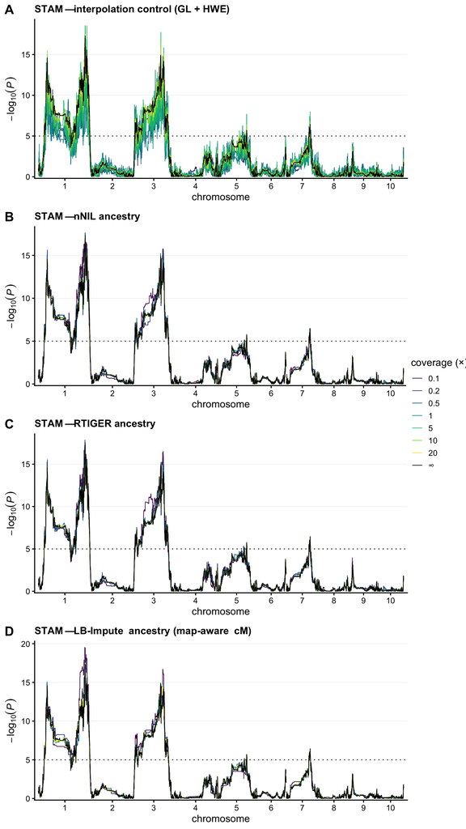

```r
pA <- plot_sweep_line(here("results/sim/teonam/stam_gwas_control_sweep.csv"),
  "STAM — interpolation control (GL + HWE)",
  legend = FALSE
)
pB <- plot_sweep_line(here("results/sim/teonam/stam_gwas_nnil_sweep.csv"),
  "STAM — nNIL ancestry",
  legend = FALSE
)
pC <- plot_sweep_line(here("results/sim/teonam/stam_gwas_rtiger_sweep.csv"),
  "STAM — RTIGER ancestry",
  legend = FALSE
)
pD <- plot_sweep_line(here("results/sim/teonam/stam_gwas_lbimpute_sweep.csv"),
  "STAM — LB-Impute ancestry (map-aware cM)",
  legend = FALSE
)
leg <- cowplot::get_legend(
  plot_sweep_line(here("results/sim/teonam/stam_gwas_rtiger_sweep.csv"), "", legend = TRUE)
)

col <- cowplot::plot_grid(pA, pB, pC, pD,
  ncol = 1, align = "v", axis = "lr",
  labels = c("A", "B", "C", "D"), label_size = 18
)
composite <- cowplot::plot_grid(col, leg, ncol = 2, rel_widths = c(1, 0.13))
ggsave(here("results/sim/teonam/stam_sweep_composite.png"), composite,
  width = 9, height = 16, dpi = 200, bg = "white"
)
composite
```